# Classification Trees

This activity on Decision Trees in R is an abbreviated version of p. 324-331 of “Introduction to Statistical Learning with Applications in R” by Gareth James, Daniela Witten, Trevor Hastie and Robert Tibshirani. It is also adapted from an implementation by Amelia McNamara and R. Jordan Crouser at Smith College.

## Fitting Classification Trees

The `rpart` library is useful for constructing classification and regression trees:

```r
library(rpart)
library(tidyverse)
```

We’ll start by using **classification trees** to analyze the `Carseats` data set.

```r
carseats <- read.csv("Carseats.csv")
```

The data set contains the following variables:

| Variable | Description |
| --- | --- |
| `Sales` | Unit sales (in thousands) at each location |
| `CompPrice` | Price charged by competitor at each location |
| `Income` | Community income level (in thousands of dollars) |
| `Advertising` | Local advertising budget for company at each location (in thousands of dollars) |
| `Population` | Population size in region (in thousands) |
| `Price` | Price company charges for car seats at each site |
| `ShelveLoc` | Quality of the shelving location for the car seats (Bad, Good or Medium) |
| `Age` | Average age of the local population |
| `Education` | Education level at each location |
| `Urban` | Is the store in an urban location (`No` or `Yes`) |
| `US` | Is the store in the US (`No` or `Yes`) |

In these data, `Sales` is a continuous variable, and so we begin by converting it to a binary variable. We use the `ifelse()` function to create a variable, called `High`, which takes on a value of `Yes` if the `Sales` variable exceeds 8, and takes on a value of `No` otherwise:

```r
carseats <- carseats %>%
  mutate(High = as.factor(ifelse(Sales <= 8, "No", "Yes")))
```

In order to properly evaluate the performance of a classification tree on the data, we must estimate the test error rather than simply computing the training error. We first split the observations into a training set and a test set:

```r
set.seed(2202017)
train <- carseats %>%
  sample_n(200)
test <- carseats %>%
  setdiff(train)
```

We now use the `rpart()` function to fit a classification tree in order to predict `High` using all variables but `Sales` (that would be a little silly…). The `rpart()` function requires two arguments:

- `formula`: a formula of the form `class ~ attributes`
- `data`: a data frame with the training observations

```r
tree_carseats <- rpart(High ~ . - Sales, data = train, method = "class")
```

The formula in the above code chunk is `High ~ . - Sales`, which indicates we will use all of the variables *except* Sales to predict the class specified in `High`.

To see the decision tree, simply print the fitted classifier

```r
tree_carseats
```

```
n= 200

node), split, n, loss, yval, (yprob)
      * denotes terminal node

 1) root 200 86 No (0.57000000 0.43000000)
   2) ShelveLoc=Bad,Medium 161 55 No (0.65838509 0.34161491)
     4) Price>=127 47  3 No (0.93617021 0.06382979) *
     5) Price< 127 114 52 No (0.54385965 0.45614035)
      10) CompPrice< 123.5 71 21 No (0.70422535 0.29577465)
        20) Price>=92.5 51  7 No (0.86274510 0.13725490) *
        21) Price< 92.5 20  6 Yes (0.30000000 0.70000000)
          42) Population< 298.5 9  4 No (0.55555556 0.44444444) *
          43) Population>=298.5 11  1 Yes (0.09090909 0.90909091) *
      11) CompPrice>=123.5 43 12 Yes (0.27906977 0.72093023)
        22) Advertising< 9 27 12 Yes (0.44444444 0.55555556)
          44) CompPrice< 129.5 7  2 No (0.71428571 0.28571429) *
          45) CompPrice>=129.5 20  7 Yes (0.35000000 0.65000000) *
        23) Advertising>=9 16  0 Yes (0.00000000 1.00000000) *
   3) ShelveLoc=Good 39  8 Yes (0.20512821 0.79487179)
     6) Price>=135.5 8  3 No (0.62500000 0.37500000) *
     7) Price< 135.5 31  3 Yes (0.09677419 0.90322581) *
```

To obtain predictions we use the `predict()` function. In the case of a classification tree, the argument `type="class"` instructs `R` to return the actual class prediction, rather than the probability that the observations falls into each class.

```r
preds <- predict(tree_carseats, type = "class")
```

With these predictions in hand, we can easily construct a confusion matrix

```r
table(Prediction = preds, Truth = train$High)
```

```
          Truth
Prediction  No Yes
       No  103  19
       Yes  11  67
```

and calculate the training accuracy and error rate

```r
mean(preds == train$High)     # training accuracy
```

```
[1] 0.85
```

```r
1 - mean(preds == train$High) # training error rate
```

```
[1] 0.15
```

We see that the training error rate is 15%.

One of the most attractive properties of trees is that they can be graphically displayed. We can use the `plot()` function to display the tree structure, and the `text()` function to display the node labels. The argument `pretty = 0` instructs `R` to include the category names for any qualitative predictors, rather than simply displaying a letter for each category:

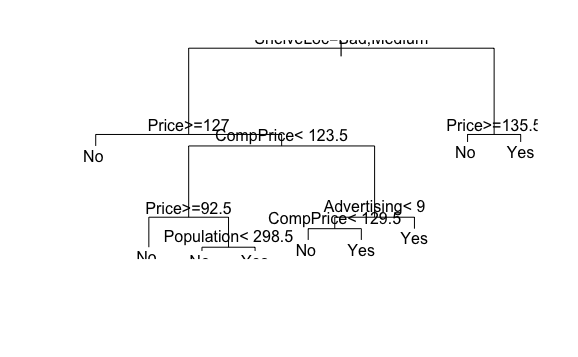

```r
plot(tree_carseats)
text(tree_carseats, pretty = 0)
```

The most important indicator of `High` sales appears to be shelving location, since the first branch differentiates `Good` locations from `Bad` and `Medium` locations.

A plot that graphics the purity of each node can be obtained using the package `partkit`:

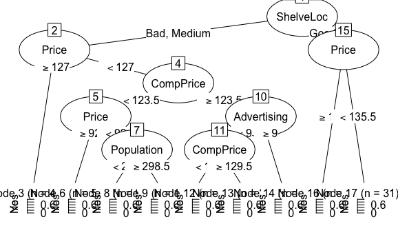

```r
library(partykit)
plot(as.party(tree_carseats))
```

A “fancier” plot can be obtained using the `rpart.plot` package, but it does not always look good for larger trees:

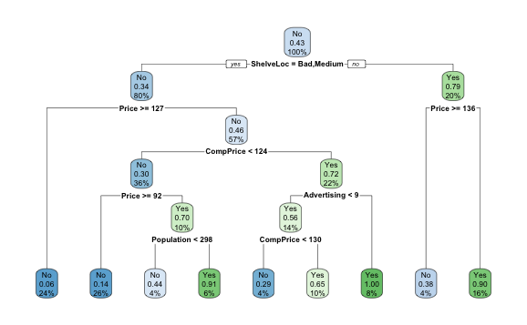

```r
library(rpart.plot)
rpart.plot(tree_carseats)
```

If we just type the name of the tree object, `R` prints output corresponding to each branch of the tree_ `R` displays the split criterion (e.g. $Price>=127$), the number of observations in that branch, the deviance, the overall prediction for the branch (`Yes` or `No`), and the fraction of observations in that branch that take on values of `Yes` and `No`. Branches that lead to terminal nodes are indicated using asterisks:

```r
tree_carseats
```

```
n= 200

node), split, n, loss, yval, (yprob)
      * denotes terminal node

 1) root 200 86 No (0.57000000 0.43000000)
   2) ShelveLoc=Bad,Medium 161 55 No (0.65838509 0.34161491)
     4) Price>=127 47  3 No (0.93617021 0.06382979) *
     5) Price< 127 114 52 No (0.54385965 0.45614035)
      10) CompPrice< 123.5 71 21 No (0.70422535 0.29577465)
        20) Price>=92.5 51  7 No (0.86274510 0.13725490) *
        21) Price< 92.5 20  6 Yes (0.30000000 0.70000000)
          42) Population< 298.5 9  4 No (0.55555556 0.44444444) *
          43) Population>=298.5 11  1 Yes (0.09090909 0.90909091) *
      11) CompPrice>=123.5 43 12 Yes (0.27906977 0.72093023)
        22) Advertising< 9 27 12 Yes (0.44444444 0.55555556)
          44) CompPrice< 129.5 7  2 No (0.71428571 0.28571429) *
          45) CompPrice>=129.5 20  7 Yes (0.35000000 0.65000000) *
        23) Advertising>=9 16  0 Yes (0.00000000 1.00000000) *
   3) ShelveLoc=Good 39  8 Yes (0.20512821 0.79487179)
     6) Price>=135.5 8  3 No (0.62500000 0.37500000) *
     7) Price< 135.5 31  3 Yes (0.09677419 0.90322581) *
```

Finally, let’s evaluate the tree’s performance on the test data.

```r
tree_pred <-  predict(tree_carseats, test, type = "class")
table(tree_pred, test$High)
```

```
tree_pred No Yes
      No  95  28
      Yes 27  50
```

What’s the estimated accuracy of the classifier?

# Pruning

Often, the tree that is produced by `rpart()` is very large, and it is often necessary to **prune** it back to obtain a **subtree**. The reason can be seen by comparing the misclassification error rates between the training data set and that found through cross-validation.

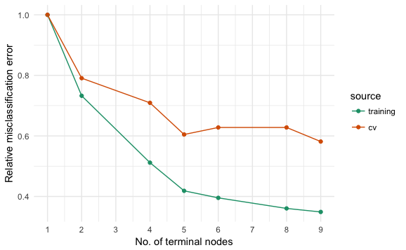

Notice that there is a point of diminishing returns: there is really no gain in accuracy past 5 terminal nodes. Consequently, we need to prune the tree to avoid **overfitting** the training data set.

The `rpart()` performs 10-fold cross-validation in the background, and the results can be seen using the `printcp()` function, or simply extracted using the below code:

```r
printcp(tree_carseats)
```

```
Classification tree:
rpart(formula = High ~ . - Sales, data = train, method = "class")

Variables actually used in tree construction:
[1] Advertising CompPrice   Population  Price       ShelveLoc

Root node error: 86/200 = 0.43

n= 200

        CP nsplit rel error  xerror     xstd
1 0.267442      0   1.00000 1.00000 0.081412
2 0.110465      1   0.73256 0.79070 0.077898
3 0.093023      3   0.51163 0.70930 0.075711
4 0.023256      4   0.41860 0.60465 0.072131
5 0.017442      5   0.39535 0.62791 0.073006
6 0.011628      7   0.36047 0.62791 0.073006
7 0.010000      8   0.34884 0.58140 0.071206
```

```r
tree_carseats$cptable
```

```
          CP nsplit rel error    xerror       xstd
1 0.26744186      0 1.0000000 1.0000000 0.08141196
2 0.11046512      1 0.7325581 0.7906977 0.07789830
3 0.09302326      3 0.5116279 0.7093023 0.07571098
4 0.02325581      4 0.4186047 0.6046512 0.07213052
5 0.01744186      5 0.3953488 0.6279070 0.07300622
6 0.01162791      7 0.3604651 0.6279070 0.07300622
7 0.01000000      8 0.3488372 0.5813953 0.07120610
```

This table has the following columns:

| Column | Explanation |
| --- | --- |
| `CP` | complexity parameter |
| `nsplit` | number of splits |
| `rel error` | scaled error in the training set (relative to the root node error) |
| `xerror` | scaled cross-validated error |
| `xstd` | cross-validated standard error of `xerror` |

To prune the tree we choose the number of splits that minimizes the cross-validation error, or can choose the point of diminishing returns.

To prune the tree in this example, we use the `prune()` function and specify the `cp` argument:

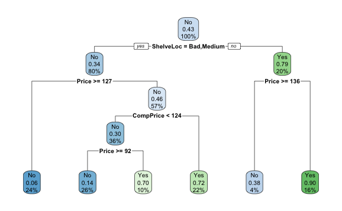

```r
pruned_tree <- prune(tree_carseats, cp = .02)
rpart.plot(pruned_tree)
```

We can also use the minimum cross-validation error:

```r
opt <- which.min(tree_carseats$cptable[,"xerror"])
opt_cp <- tree_carseats$cptable[opt, "CP"]
carseats_prune <- prune(tree_carseats, cp = opt_cp)
carseats_prune
```

```
n= 200

node), split, n, loss, yval, (yprob)
      * denotes terminal node

 1) root 200 86 No (0.57000000 0.43000000)
   2) ShelveLoc=Bad,Medium 161 55 No (0.65838509 0.34161491)
     4) Price>=127 47  3 No (0.93617021 0.06382979) *
     5) Price< 127 114 52 No (0.54385965 0.45614035)
      10) CompPrice< 123.5 71 21 No (0.70422535 0.29577465)
        20) Price>=92.5 51  7 No (0.86274510 0.13725490) *
        21) Price< 92.5 20  6 Yes (0.30000000 0.70000000)
          42) Population< 298.5 9  4 No (0.55555556 0.44444444) *
          43) Population>=298.5 11  1 Yes (0.09090909 0.90909091) *
      11) CompPrice>=123.5 43 12 Yes (0.27906977 0.72093023)
        22) Advertising< 9 27 12 Yes (0.44444444 0.55555556)
          44) CompPrice< 129.5 7  2 No (0.71428571 0.28571429) *
          45) CompPrice>=129.5 20  7 Yes (0.35000000 0.65000000) *
        23) Advertising>=9 16  0 Yes (0.00000000 1.00000000) *
   3) ShelveLoc=Good 39  8 Yes (0.20512821 0.79487179)
     6) Price>=135.5 8  3 No (0.62500000 0.37500000) *
     7) Price< 135.5 31  3 Yes (0.09677419 0.90322581) *
```

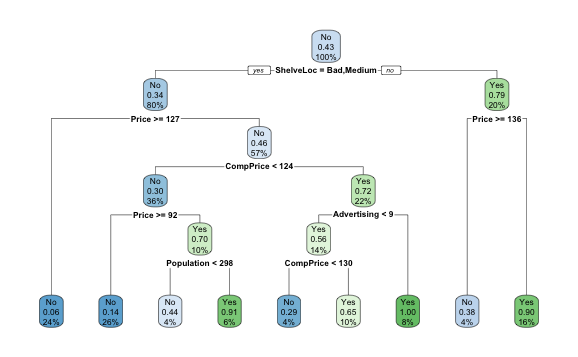

```r
rpart.plot(carseats_prune)
```

In this case, the “optimal” value of `xerror` results in the full tree, but this need not be the case.

How well does do these pruned tree perform on the test data set? Once again, we can apply the `predict()` function top find out:

```r
pruned_pred <- predict(pruned_tree, test, type = "class")
# Confusion matrix
table(pruned_pred, test$High)
```

```
pruned_pred No Yes
        No  82  16
        Yes 40  62
```

```r
# Accuracy
mean(pruned_pred == test$High)
```

```
[1] 0.72
```

Now 72% of the test observations are correctly classified, so the pruning process produced a more interpretable tree, but at a slight cost in classification accuracy.